# Effects of modifying weights on epidemiologically relevant network properties

## Aims and objectives of this report

This report provides livestock movement data owners and data managers with information about how enhancing the privacy of these data affects epidemiologically relevant network properties. The aim is to facilitate finding an appropriate balance between privacy for the livestock industry, and utility for veterinary public health practitioners and modellers.

To generate this report, a movenet-format movement data tibble was provided by the user, movement weights were modified using various functions and parameters, and the effects of these modifications were analysed on a selection of weighted network measures. These analyses were carried out for each 28 days within the data (as set via the `time_unit` argument). The report presents the results of these analyses in the form of figures with some interpretive guidance.

## Static network analyses

### Global network properties

This section describes the effects of movement weight modifications on two global network properties, average shortest path length and strength assortativity, calculated for each 28 days within the data.

#### Average shortest path length

The shortest path length or geodesic distance between a pair of nodes (holdings) in the network is the smallest number of edges (movements) needed to reach one holding from the other. The most common weighted version of this algorithm interprets edge weight as the distance (or cost) associated with an edge, and compares path lengths based on their total weighted distance (Dijkstra 1959). Considering that movement batch size is a measure of the strength of a connection, rather than a distance or cost, here edges were weighted by the reciprocal of the movement batch size ($1/{batch\_size}$) (Newman 2001). The smaller the mean weighted shortest path length is, the faster you can expect a disease to transmit between holdings, due to shorter paths and/or greater movement batch sizes.

**Alternative:** Weighting of edges according to the reciprocal of movement batch size, normalised by the average batch size in the network (${mean\_batch\_size}/{batch\_size}$). *Use of this metric is suggested by Opsahl et al., as the resulting unit of distance can be easily interpreted (as “one step with the average weight in the network”) and makes distances comparable across networks with different ranges of batch sizes (Opsahl, Agneessens, and Skvoretz 2010; Opsahl 2011).*

In Figure 1, each box represents the distribution of average shortest path lengths in the network for the 13 time periods, calculated for either the true data (left-most box in both figures) or data with batch sizes modified according to a certain treatment. In the figure on the left, batch sizes have been jittered, with the jitter range increasing from left to right along the x-axis. In the figure on the right, batch sizes have been rounded to the nearest multiple of a specified unit, with this rounding unit increasing from left to right.

**Option 2 (guidance based on linear regression trend):** The analysed data in Figure 1 show a positive trend for increasing amounts of jitter, suggesting that, in general, using larger jitter ranges would result in an overestimation of the real average shortest path length and an underestimation of the transmission potential of the network. Additionally, the data show a negative trend for increasing rounding units, suggesting that, in general, using greater rounding units would result in an underestimation of the real average shortest path length and an overestimation of the transmission potential of the network.

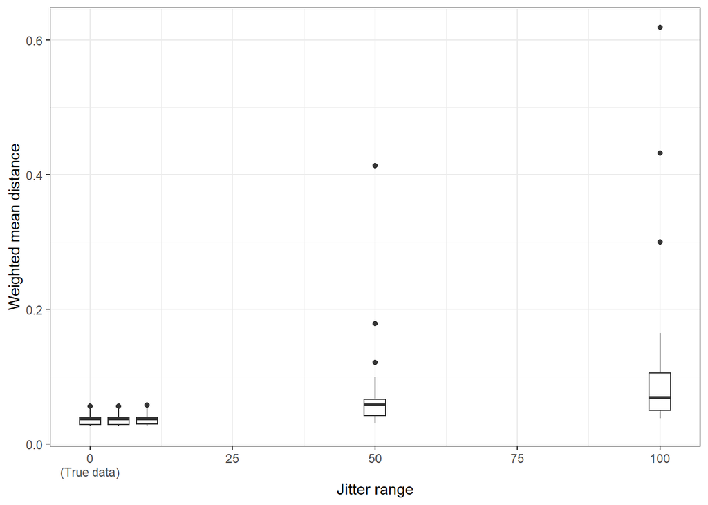

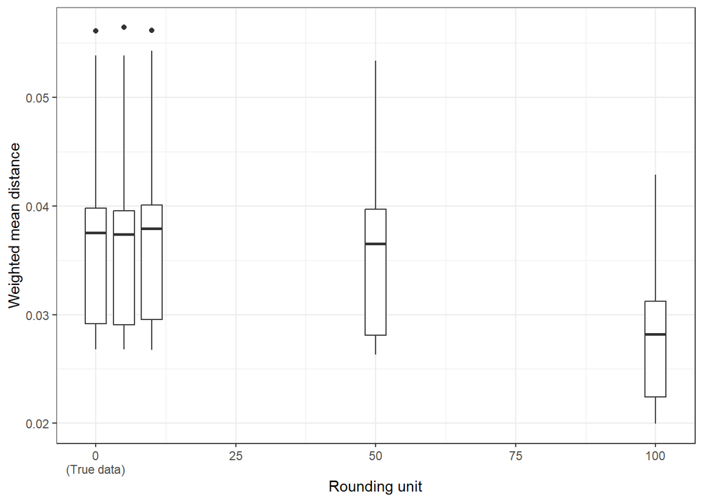

#### Strength assortativity

The strength of a node (holding) in a network is the sum of the weights of its edges. Here, this is taken to mean the sum of all movement batch sizes. Strength assortativity is a measure of the tendency of holdings with similar strength to be connected to each other. Here, we consider assortativity in a directed manner: the tendency of holdings with a particular total number of outgoing animals (out-strength) to be connected to holdings with a similar number of incoming animals (in-strength).

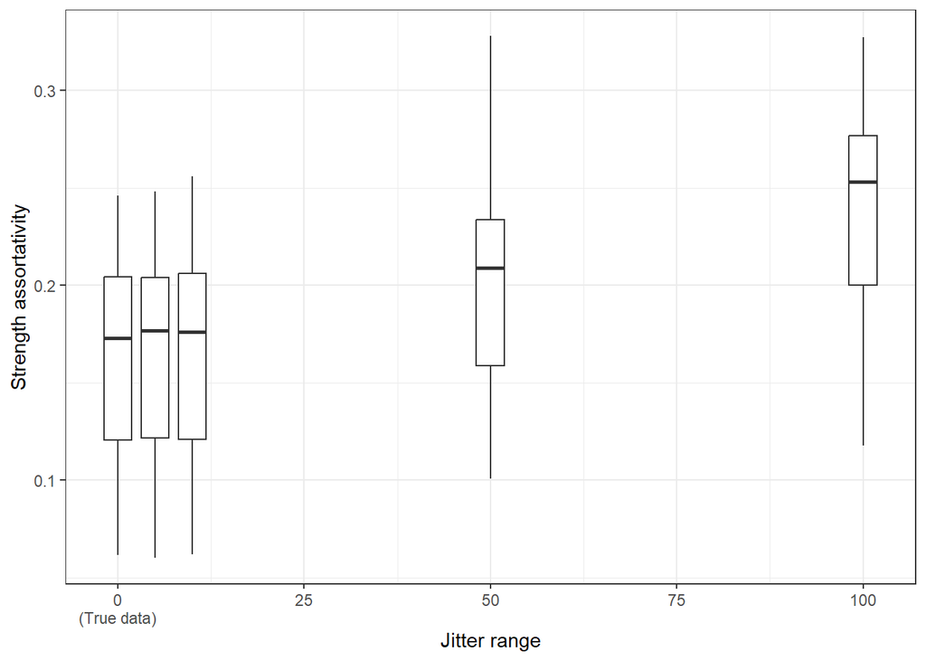

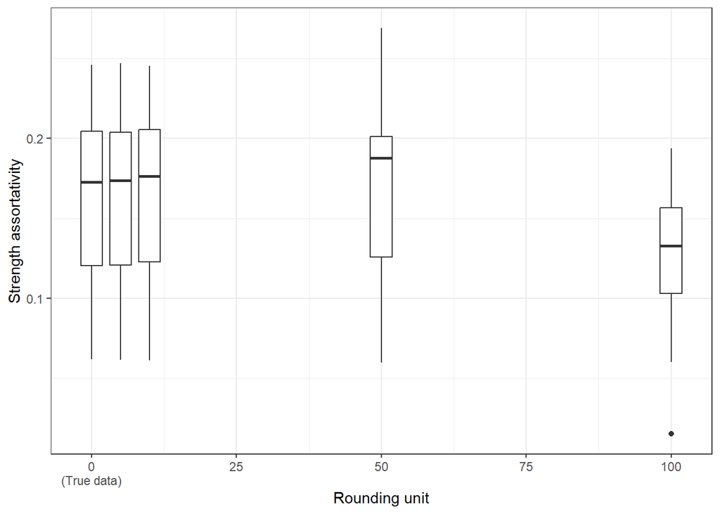

### Ranking of holdings according to local network properties

In this section, we consider the ranking of holdings according to three local “centrality” measures, which provide information about the importance of holdings in the network in terms of their connections with other holdings. The plots show how the ranking of holdings according to each centrality measure is affected by various amounts of jittering or rounding of movement batch sizes.

#### Strength centrality

The strength of a node (holding) in a network is the sum of the weights of its edges. Here, this is taken to mean the sum of all movement batch sizes. Here, holdings have been ranked according to the geometric mean of their total number of incoming animals (in-strength) and outgoing animals (out-strength), in decreasing order. The ranking in each privacy-enhanced dataset is compared to the ranking in the true dataset using Kendall’s tau rank correlation coefficient.

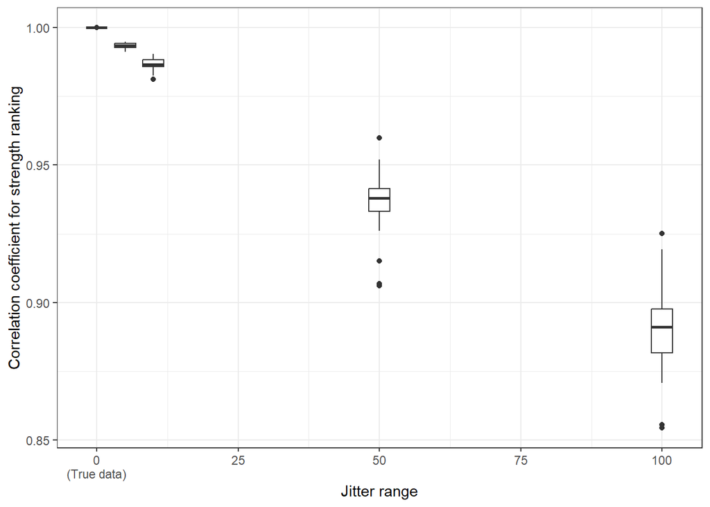

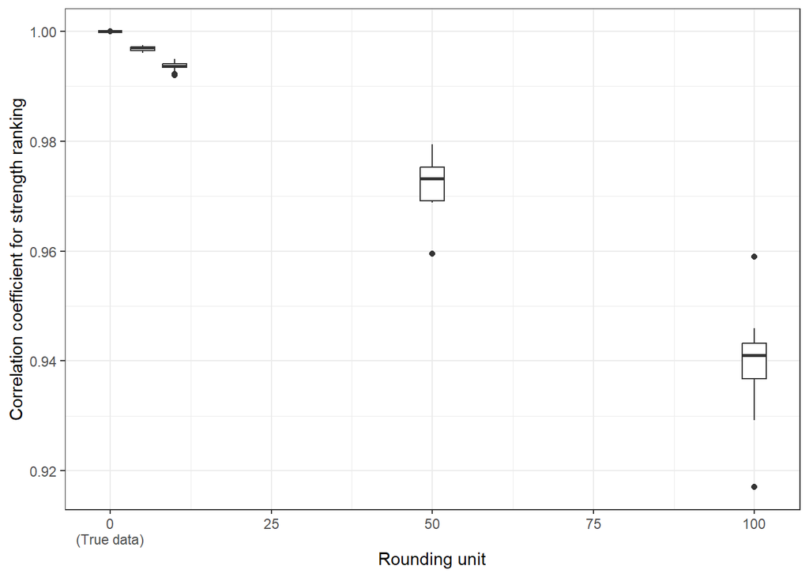

#### Betweenness centrality

The betweenness of a node (holding) in a network is the number of shortest paths between all pairs of holdings that pass through that holding. The shortest paths were determined by weighting edges according to the reciprocal of movement batch size ($1/{batch\_size}$). Here, holdings have been ranked according to their betweenness, in decreasing order. The ranking in each privacy-enhanced dataset is compared to the ranking in the true dataset using Kendall’s tau rank correlation coefficient.

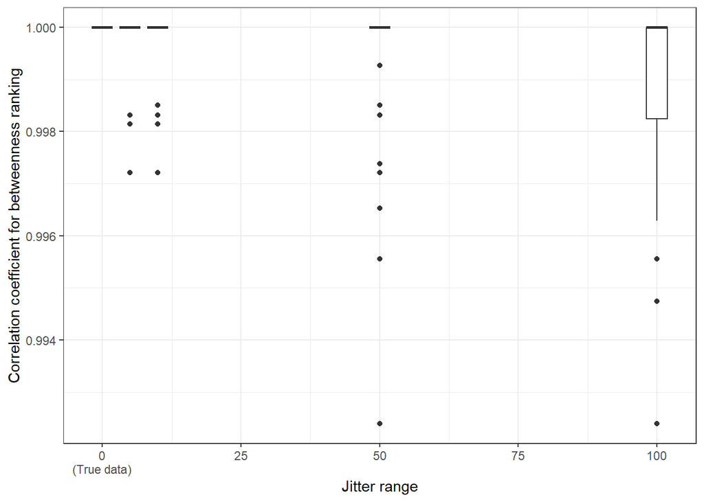

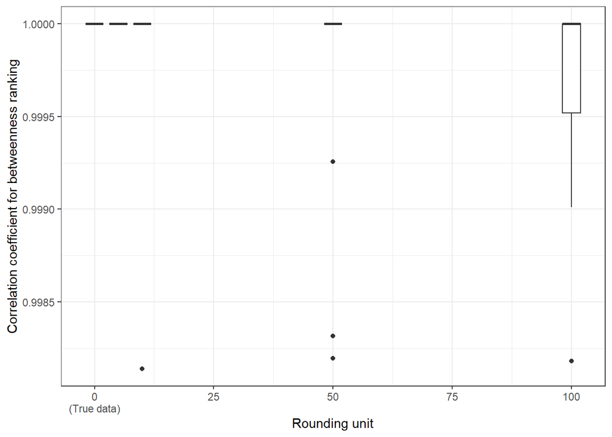

#### PageRank

The PageRank of a node (holding) in a network is a measure of its importance based on the importance of the nodes that link to it (Brin and Page 1998). To determine this, edges were weighted according to their batch sizes. Here, holdings have been ranked according to their PageRank, in decreasing order. The ranking in each privacy-enhanced dataset is compared to the ranking in the true dataset using Kendall’s tau rank correlation coefficient.

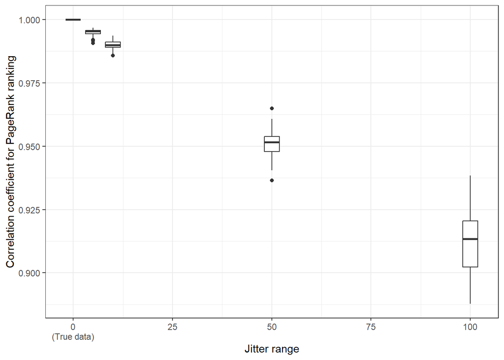

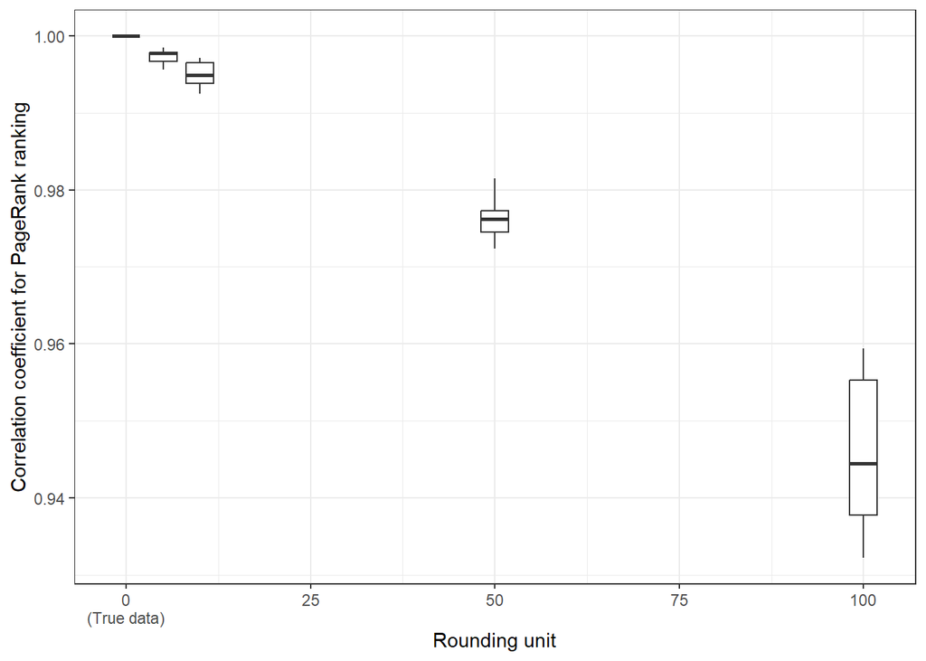

## Methods

### Initial data processing

Entries with weight (batch size) 0 or representing moves from a holding to itself (“loops”) were removed, as they were considered irrelevant for disease transmission and as potentially complicating the interpretability of analyses. Additionally, all repeated moves from and to the same holdings on the same day were aggregated into a single entry per day, with weights summed up.

### Modification of weights for privacy enhancement

Movement weights were modified with the following functions:

- [`movenet::jitter_weights()`](https://digivet-consortium.github.io/movenet/reference/jitter_weights.html): This adds random noise between `-range` and `range` to movement weights, while ensuring that resulting weights remain greater than 0. `jitter_weights()` was applied with various `range` arguments: 5, 10, 50, 100 (until the order of magnitude of the mean weight in the data). To take into account the effects of random sampling, 3 simulations were run with each `range` argument.
- [`movenet::round_weights()`](https://digivet-consortium.github.io/movenet/reference/round_weights.html): This rounds movement weights to multiples of `unit`, and also sets `unit` as the minimum possible value for the resulting weights. `round_weights()` was applied with various `unit` arguments: 5, 10, 50, 100 (until the order of magnitude of the largest weight in the data).

### Creation of network representations

Static networks were created from true and privacy-enhanced datasets, for each subsequent 28 days in the data.

During the creation of static network representations (snapshots), all repeated moves from and to the same holdings were aggregated into a single network edge per snapshot, with batch sizes summed up.

### Static network analyses (weighted)

For each static network snapshot, two weighted global network properties were determined: the average shortest path length (mean distance), and the assortativity of the network when considering in-strength and out-strength. Average shortest path length, weighting 1/batch_size Assortativity between in-strength and out-strength, weighting batch_size

Ranking of holdings according to local network properties: Betweenness, weighting 1/batch_size Strength and PageRank, weighting batch_size For strength used geometric mean between in-strength and out-strength. Holdings were ranked according to their centrality, in decreasing order. The ranking in each privacy-enhanced dataset is compared to the ranking in the true dataset using Kendall’s tau rank correlation coefficient.

Brin, Sergey, and Lawrence Page. 1998. “The Anatomy of a Large-Scale Hypertextual Web Search Engine.” *Computer Networks and ISDN Systems* 30 (1): 107–17. https://doi.org/10.1016/S0169-7552(98)00110-X.

Dijkstra, Edsger W. 1959. “A Note on Two Problems in Connexion with Graphs.” *Numerische Mathematik* 1: 269–71. https://doi.org/10.1007/BF01386390.

Newman, Mark E. J. 2001. “Scientific Collaboration Networks. II. Shortest Paths, Weighted Networks, and Centrality.” *Physical Review E* 64 (June): 016132. https://doi.org/10.1103/PhysRevE.64.016132.

Opsahl, Tore. 2011. “Shortest Paths in Weighted Networks.” https://toreopsahl.com/tnet/weighted-networks/shortest-paths/.

Opsahl, Tore, Filip Agneessens, and John Skvoretz. 2010. “Node Centrality in Weighted Networks: Generalizing Degree and Shortest Paths.” *Social Networks* 32 (3): 245–51. https://doi.org/10.1016/j.socnet.2010.03.006.